# Assignment 2

## Section 2: Repeated-Measures ANOVA

#### **Research Question:** Is there a significant change in weight satisfaction in respondants’ current weight compared to their weight at 18 years old?

```r
#Following the approach for repeated measures anova found here:
#http://www.cookbook-r.com/Statistical_analysis/ANOVA/#anovas-with-within-subjects-variables
#First I need to reshape the data from wide to long for this to work.
#This is where I'll need the unique ID variable I created earlier. I'll also need to put satwt18 and satcurwt into a single column as labels, with 'value' as their values.
longdata<-gather(rma,satis,value,satwt18:satcurwt)

#let's take a look
head(longdata)
```

```
##   code age gender ID   satis value
## 1  146  35 female  1 satwt18     5
## 2  147  37   male  2 satwt18     3
## 3  148  43 female  3 satwt18     7
## 4  149  35   male  4 satwt18     9
## 5  150  35 female  5 satwt18     4
## 6  151  35 female  6 satwt18    10
```

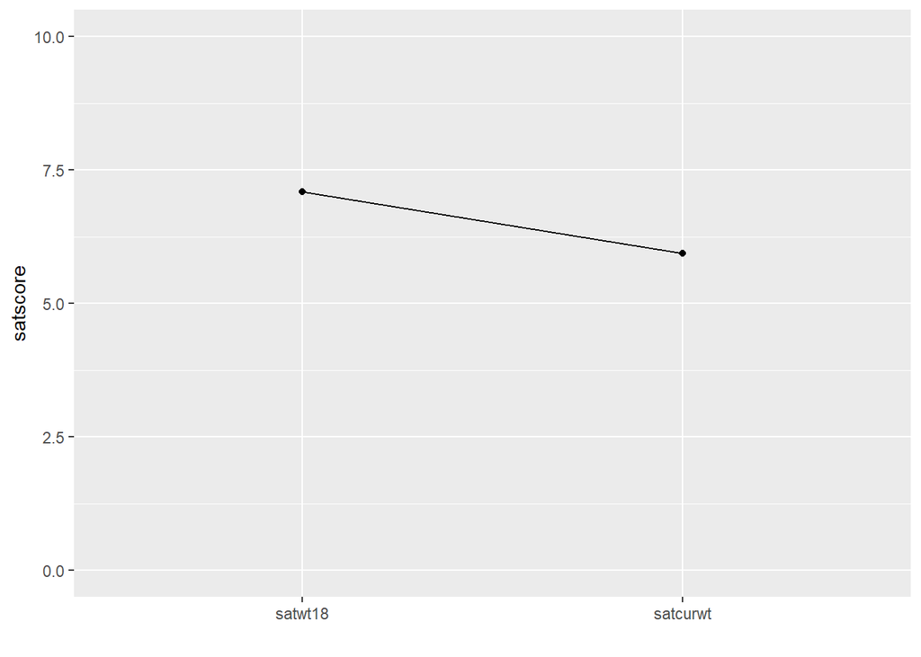

```r
#set up the data to plot. Order the factors
longdata$satis<-factor(longdata$satis, levels = c("satwt18","satcurwt"))

#group the data for plotting
p<-longdata %>% group_by(satis) %>% summarise(satscore=mean(value))

#line plot to look at the change in weight satisfaction between age 18 and current weight
p %>%
  ggplot(aes(x=satis, y=satscore, group=1)) +
  geom_line() +
  geom_point() +
  expand_limits(y=c(0,10)) +
  xlab("")
```

```r
#need to set the two timepoints (i.e., repeated IDs from the previously wide variables) as factors
longdata$ID<-factor(longdata$ID)

#Run the ANOVA
aov_long<-aov(value~satis + Error(ID/satis), data=longdata)
summary(aov_long)
```

```
##
## Error: ID
##            Df Sum Sq Mean Sq F value Pr(>F)
## Residuals 647   6355   9.822
##
## Error: ID:satis
##            Df Sum Sq Mean Sq F value Pr(>F)
## satis       1  428.3   428.3   104.7 <2e-16 ***
## Residuals 647 2646.2     4.1
## ---
## Signif. codes:  0 '***' 0.001 '**' 0.01 '*' 0.05 '.' 0.1 ' ' 1
```

```r
eta_sq(aov_long)
```

```
##        term etasq  stratum
## 1 Residuals 0.674       ID
## 2     satis 0.045 ID:satis
```

#### Results (APA Style)

A one-way within-subjects ANOVA was conducted with the factor being age and the dependant variable being weight satisfaction score. The results of ANOVA indicated a significant age effect, F(1,647) = 104.7 , p<0.001, multivariate eta-squared = 0.045. No pairwise comparisons were conducted, as only two groups were present in the ANOVA. Thus, the ANOVA shows that the mean weight satisfaction at 18 years old was significantly greater ( *M*=7.09, *SD*=2.57) than the mean weight satisfaction at the respondants’ current age ( *M*=5.94, *SD*=2.70).